# Impute Nitrogen Factors with Machine Learning

last run by: jvillasenor

March 11, 2020

## Set up and introduction

```r
suppressPackageStartupMessages({
  library(stargazer)
  library(tidymodels)
  library(furrr)
  library(tidyverse)
})

source(here::here("code","file_names.R"))
```

We have calculated sanitation factors for each country in our dataset. The sanitation factors are availabel at the country-level, but also for urban and rural populations. We want to use the urban/rural ones, as these provide a more realistic representation of wastewater treatment. The problem is that, for many countries, we only observe national-level data.

Here, we will impute urban- and rural-level sanitation factors for countries by predicting from their national values. The first step is to look at how crazy this is, so lets load the data and look at the relationship between national sanitation factors and urban and rural.

```r
nitrogen_factors <- read.csv(nitrogen_factors_fn,
                                     stringsAsFactors = F) %>%
  filter(!is.na(national_n))
```

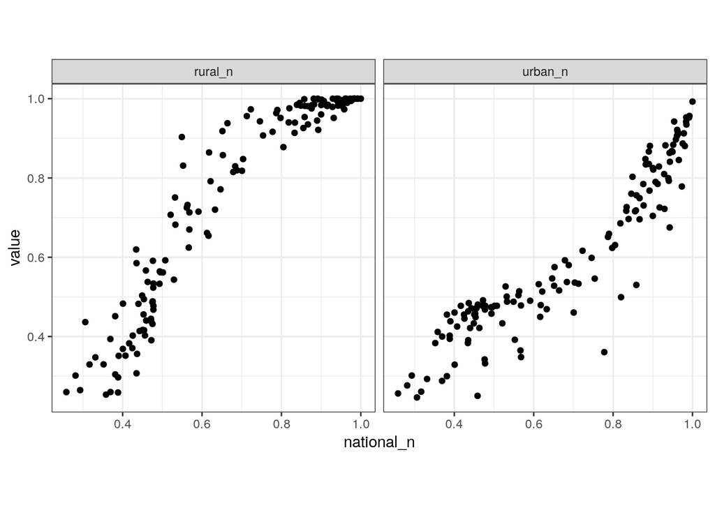

```r
nitrogen_factors %>%
  filter(!is.na(rural_n),
         !is.na(urban_n)) %>%
  select(iso3, national_n, rural_n, urban_n) %>%
  gather(variable, value, -c(iso3, national_n)) %>%
  ggplot(aes(x = national_n, y = value)) +
  geom_point() +
  facet_wrap(~variable) +
  coord_equal() +
  theme_bw()
```

Remember that $sf = 1$ implies no sanitation. With this in mind, it mkes sense that the urban sf shows a lower (cleaner) value than the national, and that the rural sf shows a higher (dirtier) value than national. Surely, other variables can explain the relationship. In this case, we will use those readily available in the detaset so as to avoid adding data from other sources. We will use population size, percent population living in urban communities, and the national-level sanitation factors.

# Balance check

Before we attempt to write some models, we want to make sure that the countries for which we have missing data are missing at random (or as if random), and that there isn’t anything systematic drving this missingness. For example, we can look at the distribution of the variables mentioned above (the ones we intend to use as predictors).

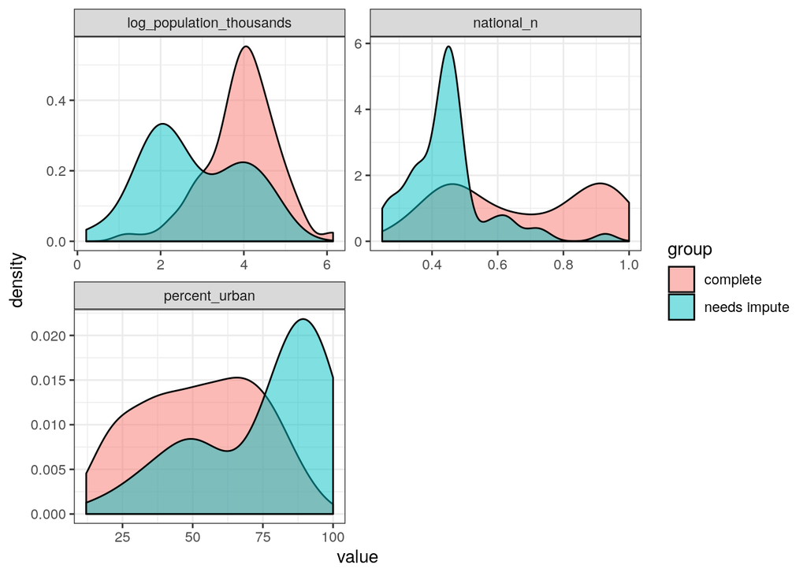

```r
nitrogen_factors %>%
  mutate(group = ifelse((is.na(urban_n) | is.na(rural_n)), "needs impute", "complete"),
         log_population_thousands = log10(population_thousands)) %>%
  select(group, national_n, log_population_thousands, percent_urban) %>%
  gather(variable, value, -group) %>%
  ggplot(aes(x = value, fill = group)) +
  geom_density(alpha = 0.5) +
  facet_wrap(~variable, scales = "free", ncol = 2) +
  theme_bw()
```

The above shows that countries in each group are a bit different. For example, countries needing imputation have smaller populations, lower national-level sanitation factors, and a greater proportion of their population living in urban environments. If we are to use these variables for prediction, we want to make sure we don’t impose a lot of linear structure. Therefore, we should try linear models, as well as more flexible approximations.

# Building predictive mdoels

## Set up tuning functions

The first step is to build a series of helper functions. Below, I’ve created two tunning functions. These will be used in the parameter tunning part. Essentially, they take a combination of tuning parameters, as given by the factorial combinations, and apply it to a split of the data (that is, to a portion of the CV splits from the 70%). These functions return the mean and standard deviation of the root mean squared error.

```r
# Function to tune random forest
tuning_rf <- function(mtry, trees, validation_data, formula){

  results <- furrr::future_map2_dfr(.x = validation_data$splits,
                                    .y = validation_data$id,
                                    ~fitting_rf(mtry = mtry,
                                                trees = trees,
                                                split = .x,
                                                id = .y,
                                                formula = formula))

  results %>%
    group_by(id) %>%
    rmse(truth, prediction) %>%
    summarise(mean_rmse = mean(.estimate),
              sd_rmse = sd(.estimate))
}

# Function to tune KNN
tuning_knn <- function(neighbors, dist, validation_data, formula){

  results <- furrr::future_map2_dfr(.x = validation_data$splits,
                                    .y = validation_data$id,
                                    ~fitting_knn(neighbors = neighbors,
                                                 dist = dist,
                                                 split = .x,
                                                 id = .y,
                                                 formula = formula))

  results %>%
    group_by(id) %>%
    rmse(truth, prediction) %>%
    summarise(mean_rmse = mean(.estimate),
              sd_rmse = sd(.estimate))
}
```

## Create fitting functions

Then I also have two fitting functions. The tunning functions above call these functions to perform the fit in each model. The actual ML process happen in these. Note that the recipe (center and scaling) is applied at the split level, not at the dataet level. This makes for more robust algorithms, and avoids overfitting or any possible spillage of “knowledge”.

```r
# Create a random forest wrapper function
fitting_rf <- function(formula, mtry, trees, split, id){

  # Extract the analysis split for this id
  analysis_set <- analysis(split)

  # Prep the recipe using the analysis set
  analysis_prep <- prep(n_recipe(analysis_set), training = analysis_set)

  # Bake (transform) the data
  analysis_processed <- bake(analysis_prep, new_data = analysis_set)

  # Fit the model
  model <- rand_forest(mtry = mtry, trees = trees, mode = "regression") %>%
    set_engine("ranger", importance = 'impurity') %>%
    fit(formula, data = analysis_processed)

  # Extract the assessment split
  assessment_set <- assessment(split)

  # Prep and bake (transform) the assessment split
  assessment_prep <- prep(n_recipe(assessment_set), testing = assessment_set)
  assessment_processed <- bake(assessment_prep, new_data = assessment_set)

  # Return a tibble with predicted and observed within the asessment data
  tibble::tibble("id" = id,
                 "truth" = assessment_processed$rural_n,
                 "prediction" = unlist(predict(model, new_data = assessment_processed)))
}

fitting_knn <- function(formula, neighbors, dist, split, id){

  # Extract the analysis split for this id
  analysis_set <- analysis(split)

  # Prep the recipe using the analysis set
  analysis_prep <- prep(n_recipe(analysis_set), training = analysis_set)

  # Bake (transform) the data
  analysis_processed <- bake(analysis_prep, new_data = analysis_set)

  # Fit the model
  model <- nearest_neighbor(mode = "regression", neighbors = neighbors, dist_power = dist) %>%
    set_engine("kknn") %>%
    fit(formula, data = analysis_processed)

  # Extract the assessment split
  assessment_set <- assessment(split)

  # Prep and bake (transform) the assessment split
  assessment_prep <- prep(n_recipe(assessment_set), testing = assessment_set)
  assessment_processed <- bake(assessment_prep, new_data = assessment_set)

  # Return a tibble with predicted and observed within the asessment data
  tibble::tibble("id" = id,
                 "truth" = assessment_processed$rural_n,
                 "prediction" = unlist(predict(model, new_data = assessment_processed)))
}
```

## Data preping

Let’s now create a subset of data for which we have national, urban, and rural sanitation factors. We will call this the training dataset (because the models will be trained on it, and then used to predict on the missing data)

```r
# Create a subset of complete data
complete <- nitrogen_factors %>%
  filter(!is.na(rural_n),
         !is.na(urban_n)) %>%
    select(percent_urban, population_thousands,
           national_n, rural_n, urban_n,
           national_n_river, rural_n_river, urban_n_river,
           rural_n_open, rural_n_septic, rural_n_treated,
           urban_n_open, urban_n_septic, urban_n_treated)

# testing and training datasets
## Split data
set.seed(43)
n_split <- initial_split(data = complete, prop = 0.7)
## Extract each split
### Training
n_train <- training(n_split)
### Testing
n_test <- testing(n_split)
```

Then, I create a recipe function to be called in each split. In this case, I will only center and scale all the predictors.

```r
## Create a recipe based on the training data
n_recipe <- function(dataset) {
  recipe(x = dataset, vars = c("rural_n", "urban_n",
                               "rural_n_river", "urban_n_river",
                               "rural_n_open", "urban_n_open",
                               "rural_n_septic", "urban_n_septic",
                               "rural_n_treated", "urban_n_treated",
                               "percent_urban", "population_thousands", "national_n", "national_n_river"),
         roles = c("outcome", "outcome",
                   "outcome", "outcome",
                   "outcome", "outcome",
                   "outcome", "outcome",
                   "outcome", "outcome",
                   "predictor", "predictor", "predictor", "predictor")) %>%
    step_center(all_predictors()) %>%
    step_scale(all_predictors())
}
```

Then, I take the training data and create the vfold object with 5 folds.

```r
# Cross validation for parameter tunning
## Create a cross_validation splits
set.seed(43)
validation_data <- vfold_cv(n_train, v = 5, repeats = 1)
```

```r
## RANDOM FOREST
## CV
formula <- as.formula("rural_n ~ population_thousands + percent_urban + national_n")

results_rf <- expand.grid(mtry = c(1:3),
            trees = c(10, 20, 50, 100)) %>%
  mutate(res = future_map2(.x = mtry,
                           .y = trees,
                           .f = tuning_rf,
                           validation_data = validation_data,
                           formula = formula)) %>%
  unnest()
```

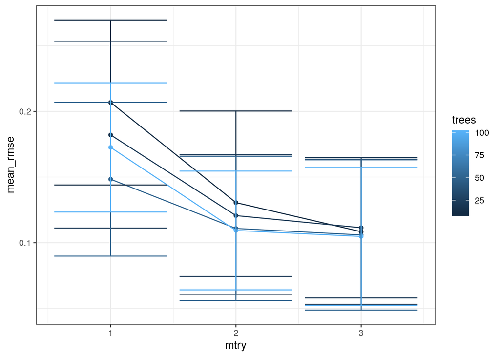

```r
### Visualize
ggplot(results_rf, aes(x = mtry, y = mean_rmse, group = trees, color = trees)) +
  geom_point() +
  geom_line() +
  geom_errorbar(aes(ymin = mean_rmse - sd_rmse, ymax = mean_rmse + sd_rmse)) +
  theme_bw()
```

```r
## KNN
### CV
results_knn <- expand.grid(neighbors = 1:10,
                           dist = c(1, 2)) %>%
  as_tibble() %>%
  mutate(res = future_map2(.x = neighbors,
                           .y = dist,
                           .f = tuning_knn,
                           validation_data = validation_data,
                           formula = formula)) %>%
  unnest()
```

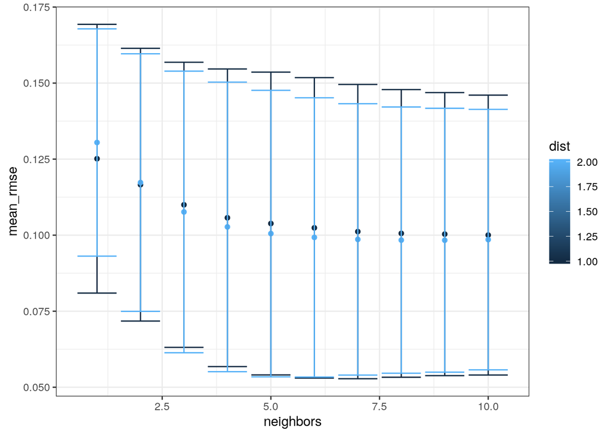

```r
### Visualize
ggplot(results_knn, aes(x = neighbors, y = mean_rmse, color = dist)) +
  geom_point() +
  geom_errorbar(aes(ymin = mean_rmse - sd_rmse, ymax = mean_rmse + sd_rmse)) +
  theme_bw()
```

```r
### Prep the recipe
training_rec <- prep(n_recipe(n_train))
### Bake the recipe
train_data <- bake(training_rec, new_data = n_train)
```

Now that we have the data, we can go ahead and use them to train the tunned algorithms.

```r
full_rf_model <- rand_forest(mtry = 2, trees = 10, mode = "regression") %>%
  set_engine("ranger", importance = 'impurity') %>%
  fit(formula, data = train_data)

full_knn_model <- nearest_neighbor(mode = "regression", neighbors = 6, dist_power = 2) %>%
  set_engine("kknn") %>%
  fit(formula, data = train_data)

full_lm_model <- linear_reg() %>%
  set_engine("lm") %>%
  fit(formula, data = train_data)
```

We then take each of these, and calculate their performance using three performance metrics. For that, I first create a wrapper function.

```r
metrics_wrap <- function(model_object, new_data) {
 model_object %>%
    predict(new_data) %>%
    bind_cols(new_data) %>%
    metrics(truth = rural_n, estimate = .pred) %>%
    select(-.estimator)
}
```

We can then apply that wrapper function on the entire data. First, we’ll prep and apply our recipte to the testing data, which has not been used up until this time. We then use the model objects from above to predict rural_n, and compare predicted to observed to derive three measures of performance.

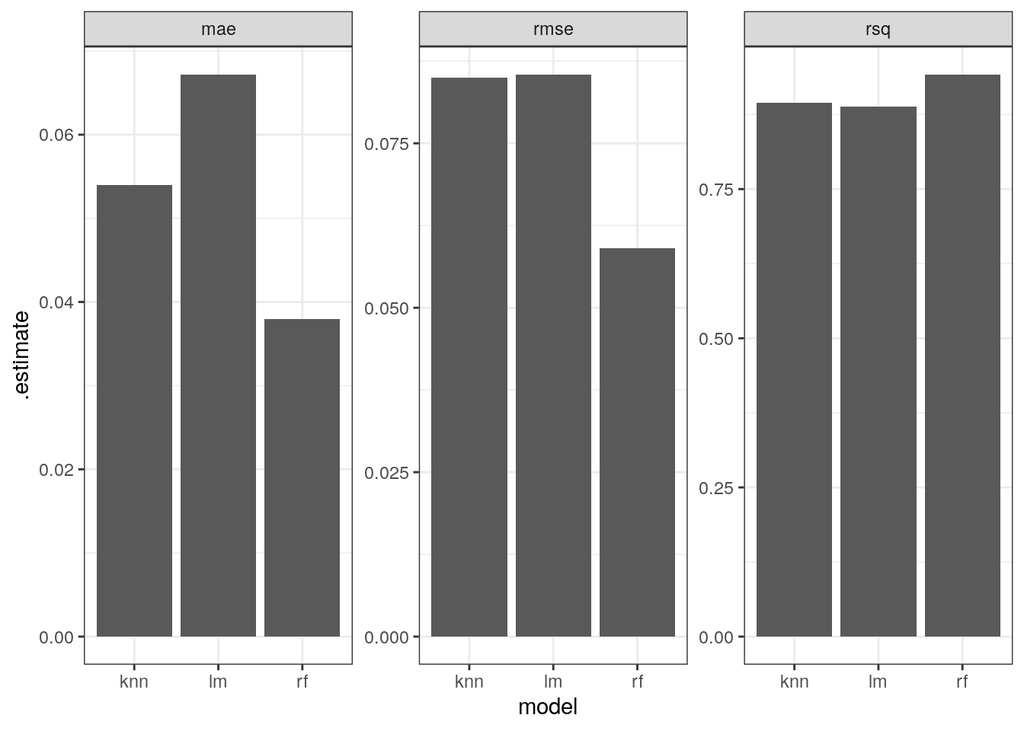

```r
# Calculate parameters for the testing set
test_rec <- n_test %>%
  prep(n_recipe(.), testing = .)

# Apply parameters to obtain a final testing set
data_test <- bake(test_rec, new_data = n_test)

tibble(model = c("rf", "knn", "lm"),
       model_object = list(full_rf_model,
                           full_knn_model,
                           full_lm_model)) %>%
  mutate(res = map(model_object, metrics_wrap, new_data = data_test)) %>%
  unnest(res) %>%
  ggplot(aes(x = model, y = .estimate)) +
  geom_col() +
  facet_wrap(~.metric, scales = "free_y") +
  theme_bw()
```

# Fitting final model

The above evaluation shows that random forests have the lowest mean average error, lowest root-mean square error, and the highest out-of-sample R squared. Therefore, we will now train a model using all the complete data, and then use it to impute rural for the missing values.

```r
### Prep the recipe
complete_rec <- prep(n_recipe(complete))
### Bake the recipe
complete_data <- bake(complete_rec, new_data = complete)

# Generate models
## RURAL
#### General
rf_rural <- rand_forest(mtry = 2, trees = 10, mode = "regression") %>%
  set_engine("ranger", seed = 43) %>%
  fit(rural_n ~ population_thousands + percent_urban + national_n, data = complete_data)

#### > 1 km from rivers
rf_rural_river <- rand_forest(mtry = 2, trees = 10, mode = "regression") %>%
  set_engine("ranger", seed = 43) %>%
  fit(rural_n_river ~ population_thousands + percent_urban + national_n_river, data = complete_data)

#### Infrastructure-specific
rf_rural_open <- rand_forest(mtry = 2, trees = 10, mode = "regression") %>%
  set_engine("ranger", seed = 43) %>%
  fit(rural_n_open ~ population_thousands + percent_urban + national_n_river, data = complete_data)

rf_rural_septic <- rand_forest(mtry = 2, trees = 10, mode = "regression") %>%
  set_engine("ranger", seed = 43) %>%
  fit(rural_n_septic ~ population_thousands + percent_urban + national_n_river, data = complete_data)

rf_rural_treated <- rand_forest(mtry = 2, trees = 10, mode = "regression") %>%
  set_engine("ranger", seed = 43) %>%
  fit(rural_n_treated ~ population_thousands + percent_urban + national_n_river, data = complete_data)

## URBAN
### General
rf_urban <- rand_forest(mtry = 2, trees = 10, mode = "regression") %>%
  set_engine("ranger", seed = 43) %>%
  fit(urban_n ~ population_thousands + percent_urban + national_n, data = complete_data)

### > 1 km from rivers
rf_urban_river <- rand_forest(mtry = 2, trees = 10, mode = "regression") %>%
  set_engine("ranger", seed = 43) %>%
  fit(urban_n_river ~ population_thousands + percent_urban + national_n_river, data = complete_data)

#### Infrastructure-specific
rf_urban_open <- rand_forest(mtry = 2, trees = 10, mode = "regression") %>%
  set_engine("ranger", seed = 43) %>%
  fit(urban_n_open ~ population_thousands + percent_urban + national_n_river, data = complete_data)

rf_urban_septic <- rand_forest(mtry = 2, trees = 10, mode = "regression") %>%
  set_engine("ranger", seed = 43) %>%
  fit(urban_n_septic ~ population_thousands + percent_urban + national_n_river, data = complete_data)

rf_urban_treated <- rand_forest(mtry = 2, trees = 10, mode = "regression") %>%
  set_engine("ranger", seed = 43) %>%
  fit(urban_n_treated ~ population_thousands + percent_urban + national_n_river, data = complete_data)
```

Now we perform the imputation by taking the models above and feeding them the incomplete data.

```r
impute <- function(var, model, data){
  preds <- predict(model, new_data = data)$.pred
  var[is.na(var)] <- preds[is.na(var)]

  return(var)
}
```

```r
### Prep the recipe
to_complete_rec <- prep(n_recipe(nitrogen_factors))
### Bake the recipe
to_complete_data <- bake(to_complete_rec, new_data = nitrogen_factors)

nitrogen_factors_imputed <- nitrogen_factors %>%
  mutate(
    imputed_ml = (is.na(urban_n) & is.na(rural_n)),
    rural_n = impute(rural_n, rf_rural, to_complete_data),
    rural_n_river = impute(rural_n_river, rf_rural_river, to_complete_data),
    rural_n_open = impute(rural_n_open, rf_rural_open, to_complete_data),
    rural_n_septic = impute(rural_n_septic, rf_rural_septic, to_complete_data),
    rural_n_treated = impute(rural_n_treated, rf_rural_treated, to_complete_data),
    urban_n = impute(urban_n, rf_urban, to_complete_data),
    urban_n_river = impute(urban_n_river, rf_urban_river, to_complete_data),
    urban_n_open = impute(urban_n_open, rf_urban_open, to_complete_data),
    urban_n_septic = impute(urban_n_septic, rf_urban_septic, to_complete_data),
    urban_n_treated = impute(urban_n_treated, rf_urban_treated, to_complete_data)
  )
```

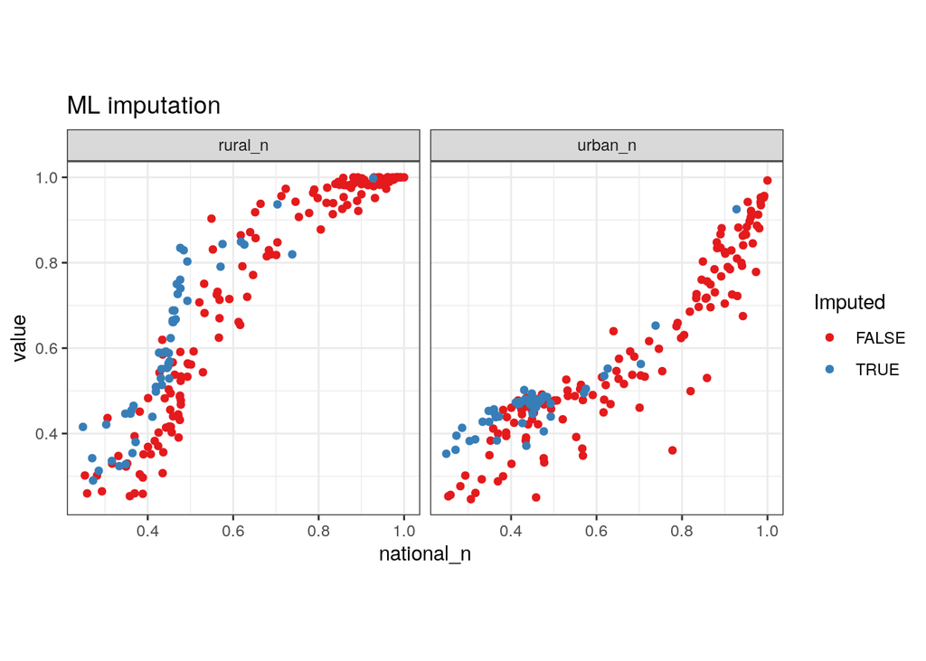

```r
nitrogen_factors_imputed %>%
  select(national_n, urban_n, rural_n, imputed_ml) %>%
  gather(class, value, -c(national_n, imputed_ml)) %>%
  ggplot(aes(x = national_n, y = value, color = imputed_ml)) +
  geom_point() +
  facet_wrap(~class) +
  theme_bw() +
  scale_color_brewer(palette = "Set1", name = "Imputed") +
  coord_equal() +
  ggtitle("ML imputation")
```

# Imputation 2

The imputation above allowed us to convert national-level sf to urban / rural sanitation factors. However, there are a couple of locations for which we have no information, and where the predictive models won’t work.

```r
# Read in the world vector data, our ultimate target
world_vector_n <- sf::st_read(world_vector_fn) %>%
  sf::st_set_geometry(NULL) %>%
  select(ISO3) %>%
  distinct() %>%
  left_join(nitrogen_factors_imputed, by = c("ISO3" = "iso3"))
# Which ones are missing?
world_vector_n %>%
  filter(is.na(rural_n)) %>%
  group_by(ISO3) %>%
  count() %>%
  ungroup() %>%
  mutate(name = countrycode::countrycode(ISO3, "iso3c", "country.name"),
         region = countrycode::countrycode(ISO3, "iso3c", "region")) %>%
  select(-n) %>%
  knitr::kable()
```

```
## Warning in countrycode::countrycode(ISO3, "iso3c", "country.name"): Some values were not matched unambiguously: CPT, XAD, XCA, XCL, XKO, XNC, XPI, XSP
```

```
## Warning in countrycode::countrycode(ISO3, "iso3c", "region"): Some values were not matched unambiguously: ATA, ATF, BVT, CCK, CPT, CXR, HMD, IOT, SGS, UMI, XAD, XCA, XCL, XKO, XNC, XPI, XSP
```

| ISO3 | name | region |
| --- | --- | --- |
| ALA | Åland Islands | Northern Europe |
| ALB | Albania | Southern Europe |
| AND | Andorra | Southern Europe |
| ARG | Argentina | South America |
| ATA | Antarctica | NA |
| ATF | French Southern Territories | NA |
| BES | Caribbean Netherlands | Caribbean |
| BLM | St. Barthélemy | Caribbean |
| BMU | Bermuda | Northern America |
| BRN | Brunei | South-Eastern Asia |
| BVT | Bouvet Island | NA |
| CCK | Cocos (Keeling) Islands | NA |
| COK | Cook Islands | Polynesia |
| CPT | NA | NA |
| CXR | Christmas Island | NA |
| ESH | Western Sahara | Northern Africa |
| FJI | Fiji | Melanesia |
| FLK | Falkland Islands | South America |
| FRO | Faroe Islands | Northern Europe |
| FSM | Micronesia (Federated States of) | Micronesia |
| GAB | Gabon | Middle Africa |
| GGY | Guernsey | Northern Europe |
| GIB | Gibraltar | Southern Europe |
| HKG | Hong Kong SAR China | Eastern Asia |
| HMD | Heard & McDonald Islands | NA |
| HRV | Croatia | Southern Europe |
| IMN | Isle of Man | Northern Europe |
| IOT | British Indian Ocean Territory | NA |
| ISR | Israel | Western Asia |
| ITA | Italy | Southern Europe |
| JEY | Jersey | Northern Europe |
| KNA | St. Kitts & Nevis | Caribbean |
| KWT | Kuwait | Western Asia |
| LTU | Lithuania | Northern Europe |
| MAC | Macau SAR China | Eastern Asia |
| MAF | Saint Martin (French part) | Caribbean |
| MCO | Monaco | Western Europe |
| MSR | Montserrat | Caribbean |
| NCL | New Caledonia | Melanesia |
| NFK | Norfolk Island | Australia and New Zealand |
| PCN | Pitcairn Islands | Polynesia |
| PRI | Puerto Rico | Caribbean |
| PYF | French Polynesia | Polynesia |
| SGP | Singapore | South-Eastern Asia |
| SGS | South Georgia & South Sandwich Islands | NA |
| SJM | Svalbard & Jan Mayen | Northern Europe |
| SPM | St. Pierre & Miquelon | Northern America |
| TKL | Tokelau | Polynesia |
| TWN | Taiwan | Eastern Asia |
| UMI | United States Minor Outlying Islands (the) | NA |
| VAT | Vatican City | Southern Europe |
| WLF | Wallis & Futuna | Polynesia |
| XAD | NA | NA |
| XCA | NA | NA |
| XCL | NA | NA |
| XKO | NA | NA |
| XNC | NA | NA |
| XPI | NA | NA |
| XSP | NA | NA |

As stated by the warning message above, the region for some of these places could not be determined. However, we can manually do it. The ones we will modify are ATF, CCK, CXR, and IOT, as seen below. In the follwoing chunk, we create the “region” variable, and use it to group our data to calculate region-level medians for each rural / urban n factors. We then use the median to replace the missing values.

```r
impute_r <- function(var, medians){
  var[is.na(var)] <- medians[is.na(var)]
  return(var)
}
```

```r
# Start imputation
nitrogen_factors_imputed <- world_vector_n %>%
  mutate(region = countrycode::countrycode(
    sourcevar = ISO3,
    origin = "iso3c",
    destination = "region"
  )) %>%
  mutate(
    region = case_when(
      ISO3 == "ATF" ~ "Eastern Africa",
      ISO3 == "CCK" ~ "South-Eastern Asia",
      ISO3 == "CXR" ~ "South-Eastern Asia",
      ISO3 == "IOT" ~ "Southern Asia",
      T ~ region
    )
  ) %>%
  select(ISO3, region, population_thousands, contains("n"), imputed_ml) %>%
  group_by(region) %>%
  mutate(
    national_n_median = median(national_n, na.rm = T),
    rural_n_median = median(rural_n, na.rm = T),
    urban_n_median = median(urban_n, na.rm = T),
    rural_n_river_median = median(rural_n_river, na.rm = T),
    urban_n_river_median = median(urban_n_river, na.rm = T),
    rural_n_open_median = median(rural_n_open, na.rm = T),
    urban_n_open_median = median(urban_n_open, na.rm = T),
    rural_n_septic_median = median(rural_n_septic, na.rm = T),
    urban_n_septic_median = median(urban_n_septic, na.rm = T),
    rural_n_treated_median = median(rural_n_treated, na.rm = T),
    urban_n_treated_median = median(urban_n_treated, na.rm = T)
  ) %>%
  ungroup() %>%
  mutate(
    imputed_r = as.character(is.na(urban_n) | is.na(rural_n)),
    national_n = impute_r(national_n, national_n_median),
    rural_n = impute_r(rural_n, rural_n_median),
    urban_n = impute_r(urban_n, urban_n_median),
    rural_n_river = impute_r(rural_n_river, rural_n_river_median),
    urban_n_river = impute_r(urban_n_river, urban_n_river_median),
    rural_n_open = impute_r(rural_n_open, rural_n_open_median),
    urban_n_open = impute_r(urban_n_open, urban_n_open_median),
    rural_n_septic = impute_r(rural_n_septic, rural_n_septic_median),
    urban_n_septic = impute_r(urban_n_septic, urban_n_septic_median),
    rural_n_treated = impute_r(rural_n_treated, rural_n_treated_median),
    urban_n_treated = impute_r(urban_n_treated, urban_n_treated_median),
  ) %>%
  select(-contains("_median"))
```

```
## Warning in countrycode::countrycode(sourcevar = ISO3, origin = "iso3c", : Some values were not matched unambiguously: ATA, ATF, BVT, CCK, CPT, CXR, HMD, IOT, SGS, UMI, XAD, XCA, XCL, XKO, XNC, XPI, XSP
```

As an example of the data, the plot below shows the known values (or those imputed through the ML process), and the imputed values.

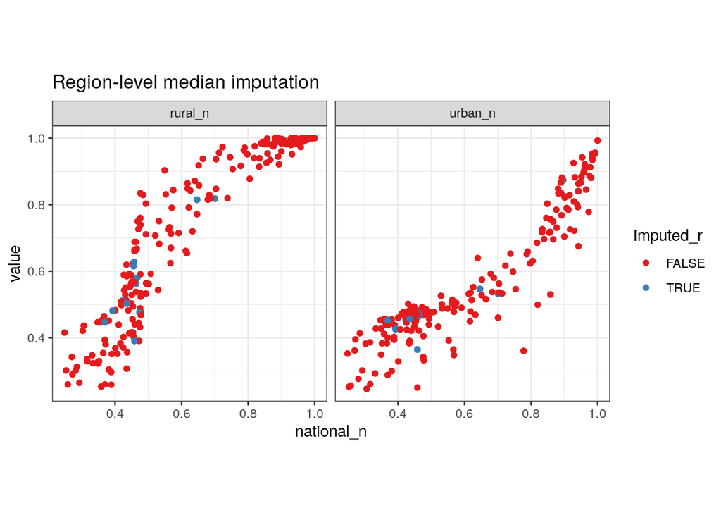

```r
nitrogen_factors_imputed %>%
  select(rural_n, urban_n, national_n, imputed_r) %>%
  gather(class, value, -c(national_n, imputed_r)) %>%
  ggplot(aes(x = national_n, y = value, color = imputed_r)) +
  geom_point() +
  facet_wrap(~class) +
  theme_bw() +
  scale_color_brewer(palette = "Set1") +
  coord_equal() +
  ggtitle("Region-level median imputation")
```

```r
write.csv(nitrogen_factors_imputed,
          file = nitrogen_factors_imputed_fn,
          row.names = F)
```